# Lab Sheet 6 - solutions

STAT260, University of Otago

Sem. 2, 2021

# Task 1

- `Education`: the number of years of education
- `South`: Indicator variable for Southern region (1 = Southern, 0 = not Southern)
- `Sex`: Indicator variable for sex (1 = female, 0 = male)
- `Experience`: Number of years of work experience
- `Union`: Indicator variable for union membership (1 = member, 0 = not member)
- `Wage`: dollars per hour
- `Age`: age (years)
- `Race`: 1 = other, 2 = Hispanic, 3 = white
- `Occupation`: 1 = management, 2 = sales, 3 = clerical, 4 = service, 5 = professional, 6 = other
- `Sector`: 0 = other, 1 = manufacturing, 2 = construction
- `Marr`: Indicator variable for marital status (1 = married, 0 = not married)

Call these data into R in the space below. Use `str` to examine the structure of the data. Can you see any potential issues with how the categorical variables (e.g., sex, race, occupation etc) have been recorded?

*Answer:*

```r
data <- read.csv('../lab04/cps.csv', header = TRUE)
str(data)
```

```
## 'data.frame':    534 obs. of  11 variables:
##  $ Education : int  8 9 12 12 12 13 10 12 16 12 ...
##  $ South     : int  0 0 0 0 0 0 1 0 0 0 ...
##  $ Sex       : int  1 1 0 0 0 0 0 0 0 0 ...
##  $ Experience: int  21 42 1 4 17 9 27 9 11 9 ...
##  $ Union     : int  0 0 0 0 0 1 0 0 0 0 ...
##  $ Wage      : num  5.1 4.95 6.67 4 7.5 ...
##  $ Age       : int  35 57 19 22 35 28 43 27 33 27 ...
##  $ Race      : int  2 3 3 3 3 3 3 3 3 3 ...
##  $ Occupation: int  6 6 6 6 6 6 6 6 6 6 ...
##  $ Sector    : int  1 1 1 0 0 0 0 0 1 0 ...
##  $ Marriage  : int  1 1 0 0 1 0 0 0 1 0 ...
```

# Task 2

Use `ggplot` to produce boxplots of `Wages` against `Union`. You will need to use the `as.factor` function to specify Union Membership as the x variable in the plot aesthetics. What is the issue if `as.factor` is not used? Ensure that the axis labels and plot title are well specified (please do this for all plots).

*Answer:*

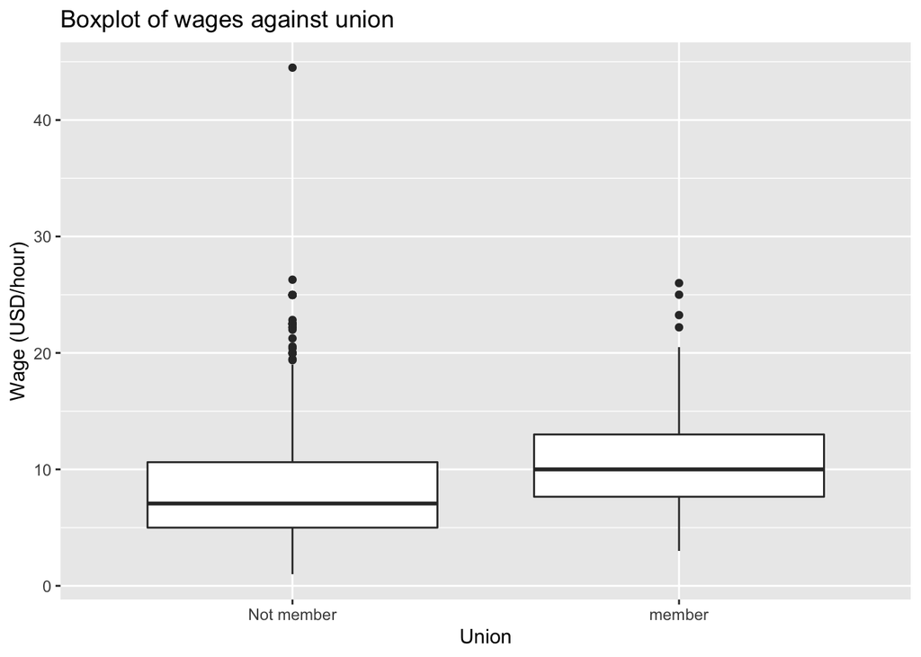

```r
data %>% ggplot(aes(y = Wage, x = factor(Union, label = c("Not member", "member"))))+
  geom_boxplot()+
  ggtitle("Boxplot of wages against union")+
  xlab("Union")+
  ylab("Wage (USD/hour)")
```

# Task 3

Add the raw data points to the plot you made above, selecting an appropriate width for the jittering. Try adjusting the alpha level in `geom_jitter` - what effect does this have on the data points? Note that outliers are plotted twice (once in each layer) - can you find a way to omit the outliers from the boxplot layer? (HINT: think about the alpha level of the outliers, and have a lot at the parameter options on the `geom_boxplot` help page).

*Answer:*

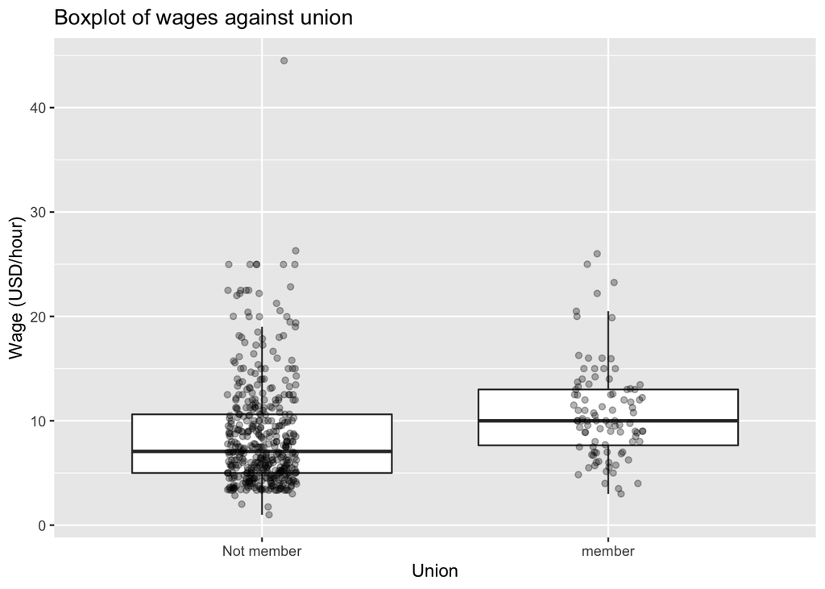

```r
data %>% ggplot(aes(y = Wage, x = factor(Union, label = c("Not member", "member"))))+
  geom_boxplot(outlier.alpha = 0)+
  geom_jitter(width = 0.1, alpha = 0.3)+
  ggtitle("Boxplot of wages against union")+
  xlab("Union")+
  ylab("Wage (USD/hour)")
```

# Task 4

Generate overlapping density plots for the wage *versus* union membership data. Remember that you will need to use `as.factor` when specifying `Union` as the `fill` variable. Which type of plot do you find more informative, boxplots or density plots? Why?

*Answer:*

The density plot is a better plot for this data. This is because it it gives more insight to the distribution of data.

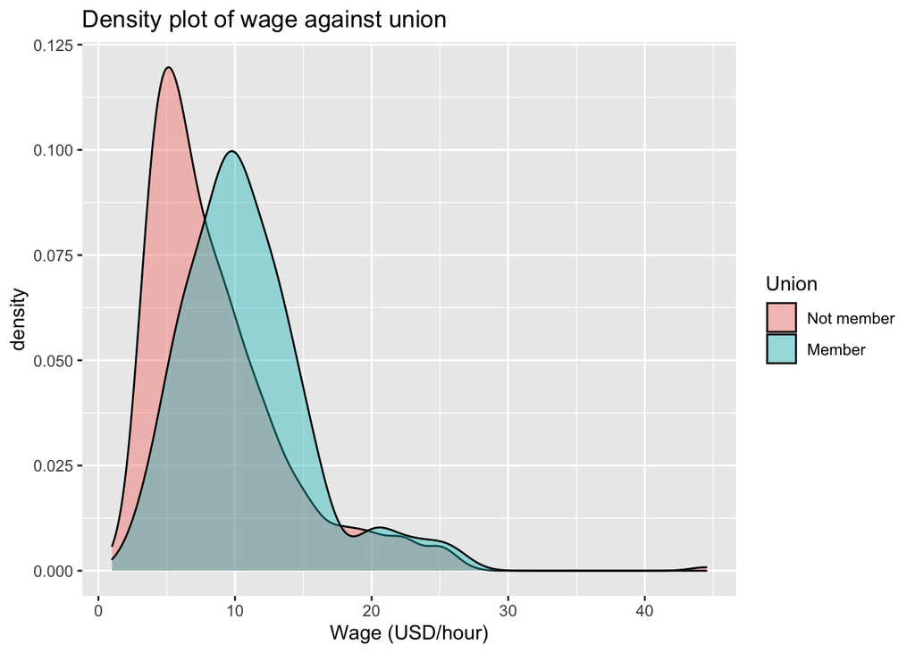

```r
data %>%
  ggplot(aes(x = Wage, fill = factor(Union, labels = c("Not member", "Member"))))+
  geom_density(alpha = 0.4)+
  ggtitle("Density plot of wage against union")+
  labs(fill = "Union", x = "Wage (USD/hour)")
```

# Task 5

Produce a plot comparing wage to experience, where we allow the colour to depend on each individual’s race.

*Answer:*

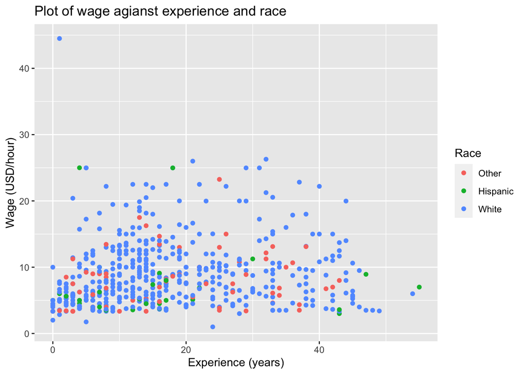

```r
data %>%
  ggplot(aes(x = Experience, y = Wage, color = factor(Race, labels = c("Other", "Hispanic", "White"))))+
  geom_point()+
  ggtitle("Plot of wage agianst experience and race")+
  labs(color = "Race", x = "Experience (years)", y = "Wage (USD/hour)")
```

# Task 6

Modify the plot from Task 5 so that the race names are used in the legend instead of the numbers, and the legend title is “Race”. HINT: use the commands `scale_colour_discrete` (you need to set the `labels` parameter within this function) and `labs` (you need to set the `colour` parameter to the label you want - see the first example on the help page).

*Answer:*

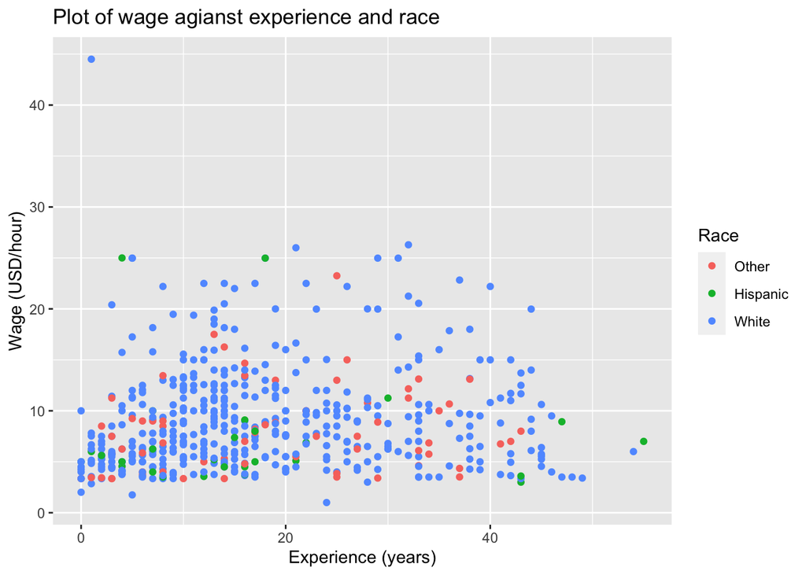

```r
data %>%
  ggplot(aes(x = Experience, y = Wage, color = as.factor(Race)))+
  geom_point()+
  ggtitle("Plot of wage agianst experience and race")+
  labs(color = "Race", x = "Experience (years)", y = "Wage (USD/hour)")+
  scale_color_discrete(labels = c("Other", "Hispanic", "White"))
```